# How does the end of Unemployment Insurance benefits affect MAU numbers?

Dani Mermelstein

2020-07-01

# Context

As of July 2020, the US is in the middle of an unemployment crisis. The Bureau of Labor Statistics in a [recent release](https://www.bls.gov/news.release/pdf/empsit.pdf) listed the unemployment rate at 11.1%, down from ~15%, which would be 17.8MM people. Compare that to the unemployment rate of 3.5% in February (5.8MM people) of this year.

In this crisis our users have been receiving unemployment checks in their N26 accounts as part of the stimulus package. In light of conversations in Congress about whether to extend the special unemployment benefits past July (see [this](https://www.fastcompany.com/90526168/600-unemployment-benefit-will-it-be-extended-heres-the-latest-as-congress-drags-its-feet) or [this](https://www.forbes.com/sites/jrose/2020/07/06/600-federal-unemployment-checks-to-be-extended/#cca4db3778fa) article), we figure this is a good time to explore broadly what would happen to our MAUs if that income was no longer available to them.

# Methodology

We identify users receiving UI benefits between 2020-03-01 and 2020-07-10. We then gather their average monthly outflows, UI and non-UI monthly inflows, and current balance at N26. We then calculate for every user how long their balance might last under the following scenarios:

1. The user continues to receive the non-UI income they got in June, but not the UI income
2. The user does not receive any more income at all going forward

## Assumptions

These are admittedly very crude projections but they serve as an important thought experiment. Here are some of the things we are assuming or not controlling for:

- We are not taking into account cyclical/seasonal events (eg rent is paid in a lump sum at the beginning of the month)
- We don’t know if our users hold balances at other banks
- We don’t know if users have income outside of N26 (ie cash, other checking accounts)
- For simplicity we assume spending will not change despite a loss of income
- We assume users are independent and are not householded, even though a spouse might still have a job
- We don’t take into consideration the time of month this analysis is performed (eg we use most current balance, not balance at day X in the month)

# Scenario 1: Some Income

**Recap:** Users retain their non-UI income from June (most recent month at time of analysis). What happens?

We have data on 3020 users with UI and non-UI June inflows, avg outflow amounts from recent months, and currently OPEN accounts at N26. These are their median stats:

- Median UI income: $6,176.50
- Median non-UI income: $504.44
- Median current balance: $210.87
- Median monthly outflows: -$4,987.99

So for each user we can do the following calculation:

> (current balance + non-UI inflows) / avg outflows * 30

to find out how many days it will take for them to draw down their account. If the number is greater than 30 days, their non-UI inflows are greater than their average monthly outflows.

And so we get a median of 9 days before users run out of money, and 86% of users in this group don’t have enough funds to ride out 30 days.

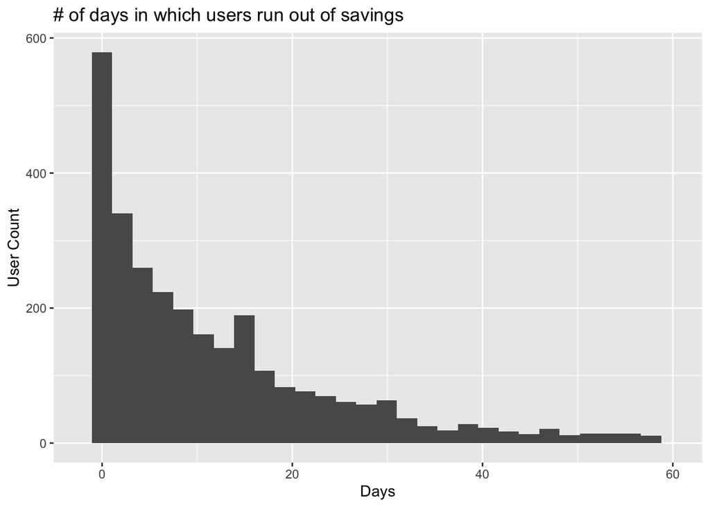

## MAU impact

If we assume that once a user draws down their balance they will have no more additional income, we can project when they will become lapsed users. In this scenario, independent from regular lapse rates and using our current MAU number of 31000, we’re potentially looking at 1% to 8% of total MAUs lapsing within 35-65 days from the date of this analysis.

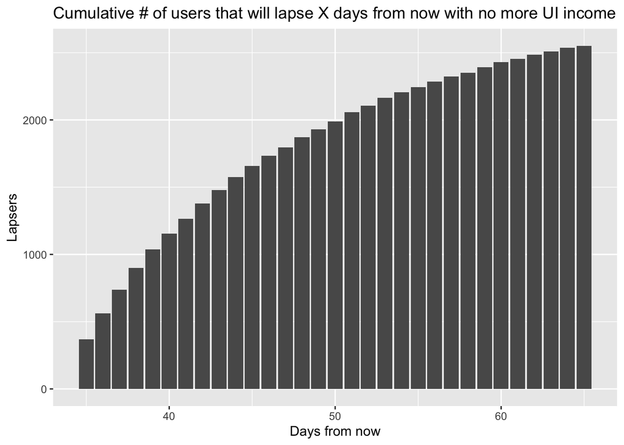

# Scenario 2: No Income

**Recap:** Users have no more income at all. What happens in this worst-case scenario?

We have data on 4378 users who have received UI deposits, avg outflow amounts from recent months, and have currently OPEN accounts at N26. These are their median stats:

- Median current balance: $94.36
- Median monthly outflows: -$4,050.40

In this case for each user we do the following calculation:

> current balance / avg outflows * 30

to find out how many days it will take for them to draw down their account. If the number is greater than 30 days, their non-UI inflows are greater than their average monthly outflows.

And so we get a median of 1 days before users run out of money, and 93% of users in this group don’t have enough funds to ride out 30 days.

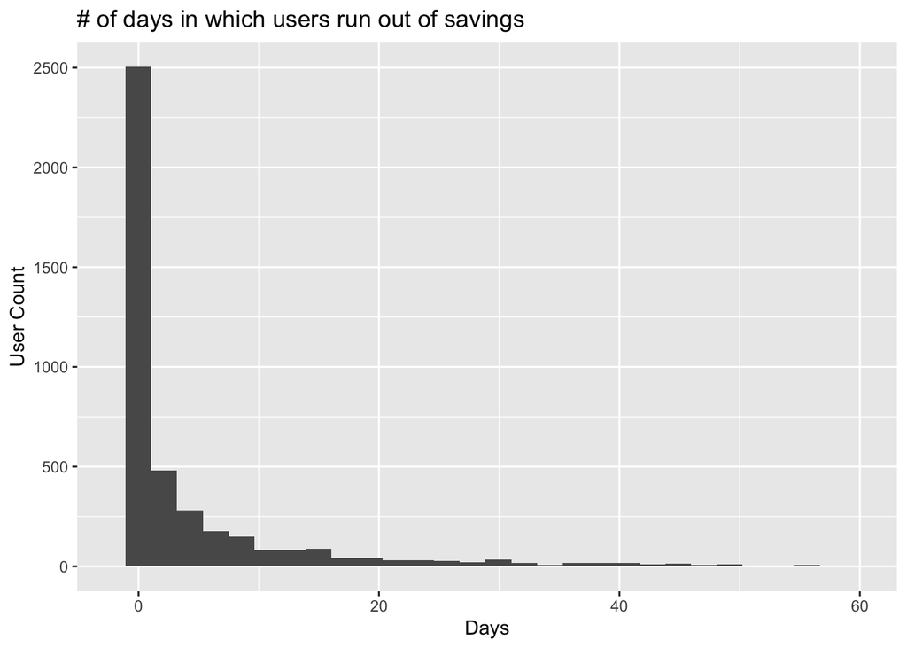

## MAU impact

If we assume that once a user draws down their balance they will have no more additional income, we can project when they will become lapsed users. In this scenario, independent from regular lapse rates and using our current MAU number of 31000, we’re potentially looking at 7% to 13% of total MAUs lapsing within 35-65 days from the date of this analysis.

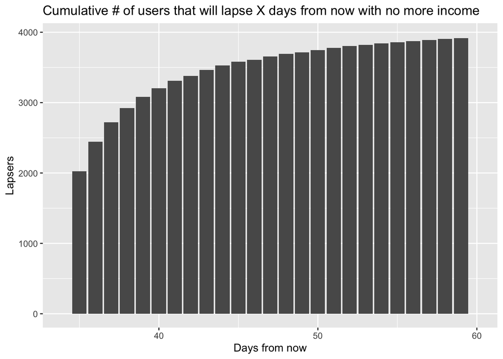

# Appendix

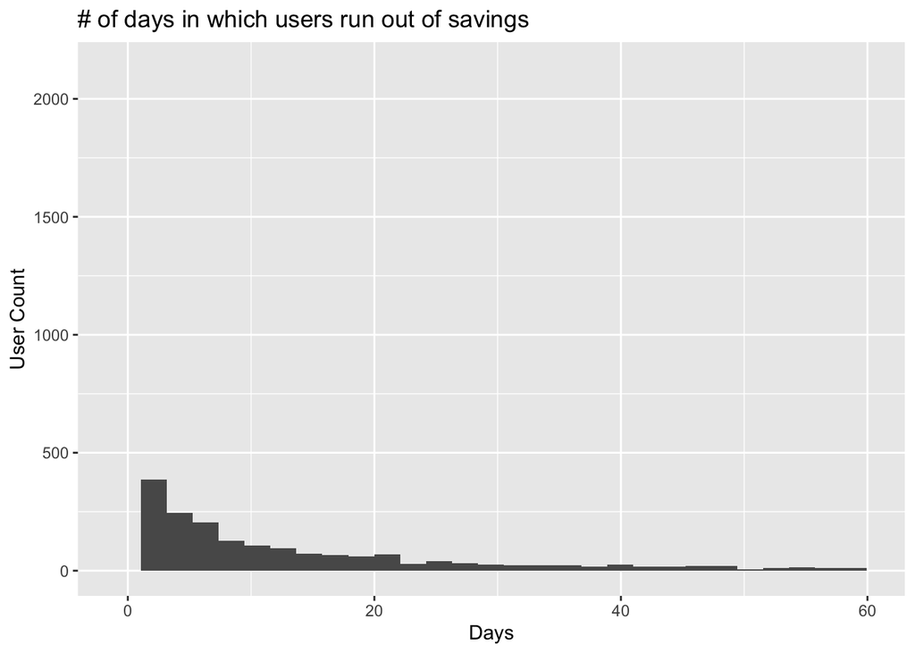

```
## [1] 1
```

```
## [1] "$3,336,399"
```

```
## [1] "-$12,396,258"
```

```
## [1] 0.05
```

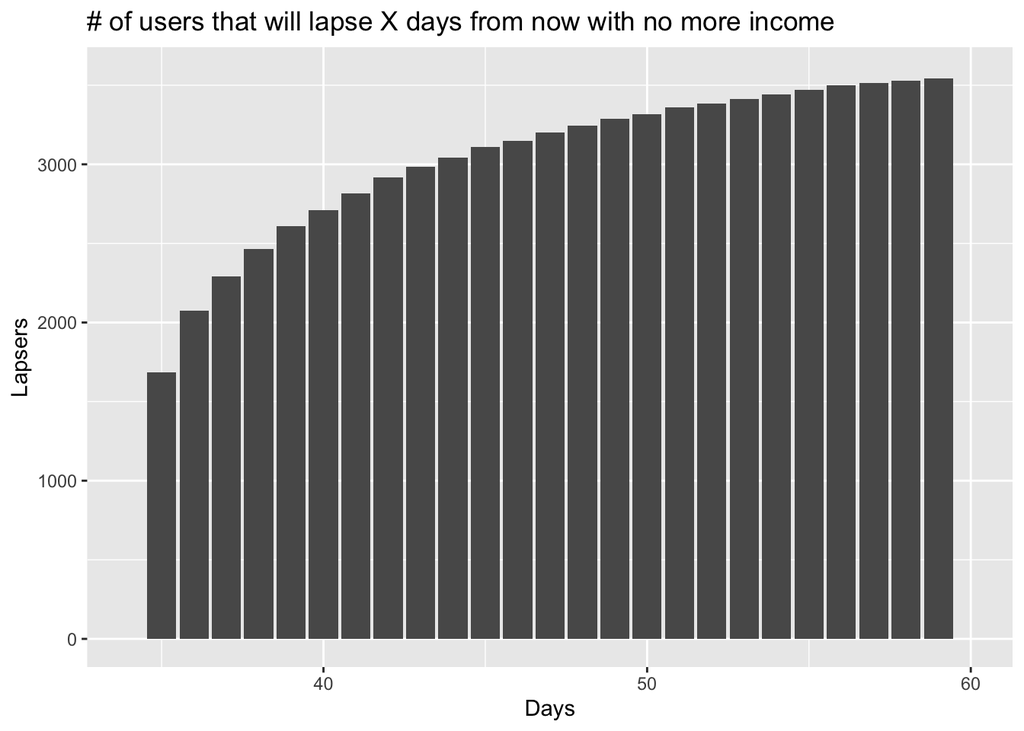

## direct deposit

```
##    users      june        ui
## 1:  8964 0.8078983 0.1431281
```

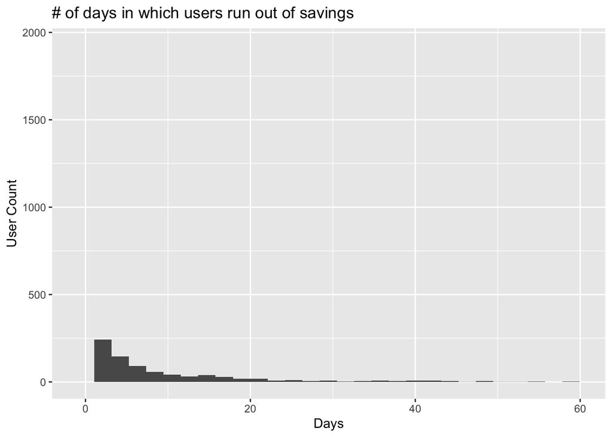

```
## [1] 0
```

```
## [1] "$1,238,728"
```

```
## [1] 2.89
```

```
## [1] "-$10,282,817"
```

```
## [1] -2043.862
```

```
## [1] 0.01
```

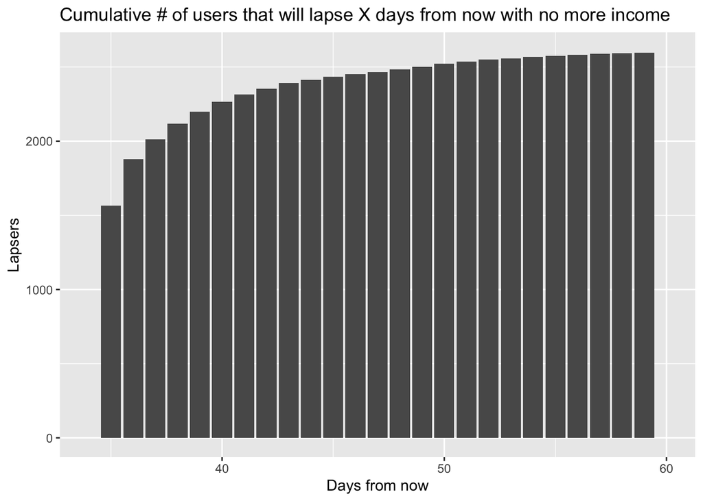